# Life history strategies and host-parasite coevolution

### Learning objectives

- Appreciate the multiple forms parasites can take
- Be able to define general parasite terms (e.g., obligate, facultative, etc.)
- Understand parasite life history tradeoffs
- Be able to quantify parasite specialism

### Parasite diversity

### How do we really define parasite diversity?

**Diversity in:**

- numbers
- phylogenetics
- infection modes
- tissue infected
- impacts
- host specificity
- …

### Diversity in numbers

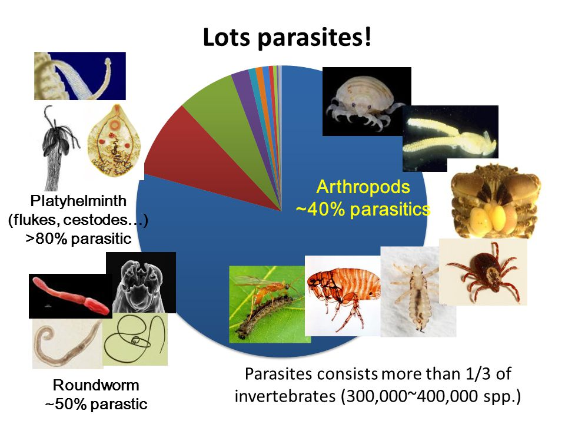

### Diversity in phylogenetics

- A host is infected with two parasite species
  - they could be closely related parasites, or quite distantly related parasites
- So when quantifying parasite diversity (either within a region or within a host species), considering the phylogenetic distance between parasites can be used as a measure of diversity

### Phylogenetic diversity for free-living animals

### Quantifying phylogenetic diversity for parasites

### Diversity in infection modes

- macroparasites versus microparasites
- direct versus indirect transmission
- simple versus complex life cycle

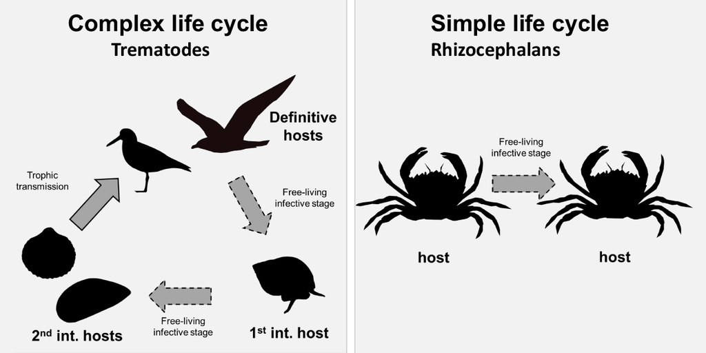

### Env-transmitted pathogen (simple)

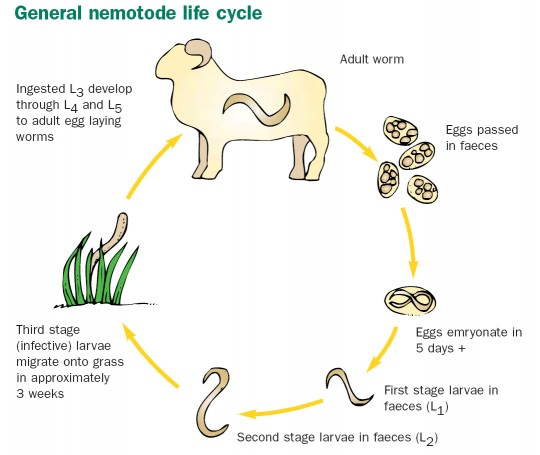

### Complex life cycle

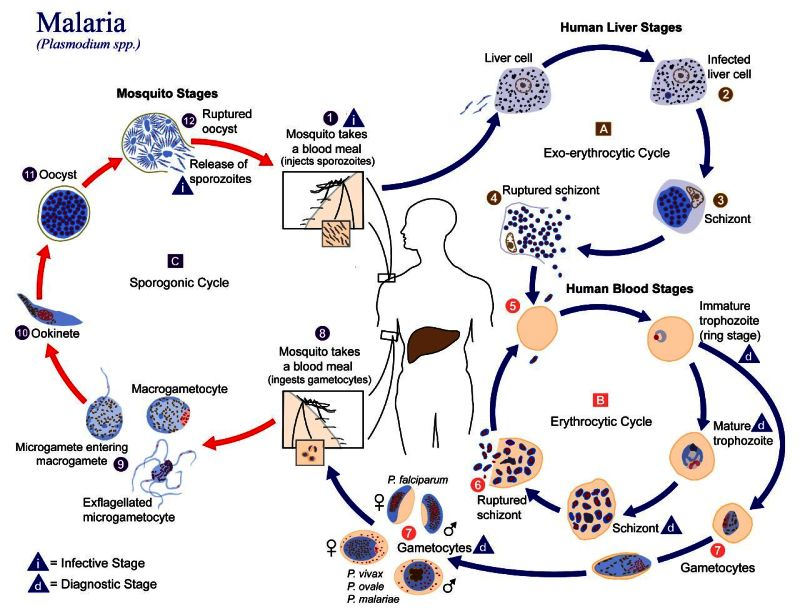

### Diversity in infection modes

- Six parasite strategies:
  - parasitic castration
  - directly transmitted parasitism
  - trophically-transmitted parasitism
  - vector-transmitted parasitism
  - parasitoidism
  - micropredation

### parasitic castrators

- remove the host’s ability to reproduce
- take that energy and/or space

### directly transmitted parasitism

- do not require vector
- this includes environmentally-transmitted pathogens (e.g., cholera, many intestinal helmiths)

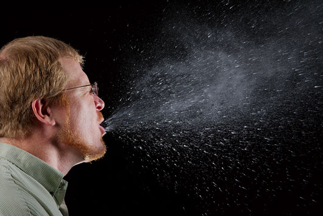

### trophically-transmitted parasitism

- transmitted through predation of the host
- complex life cycle parasites
- can modify host behavior

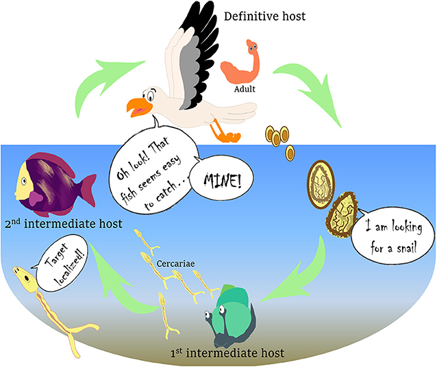

### vector-transmitted parasitism

- Rely on other organisms for transmission (e.g., mosquitos, ticks, lice, fleas, etc.)
- Sometimes reproduce in vector, sometimes only reproduce in definitive host

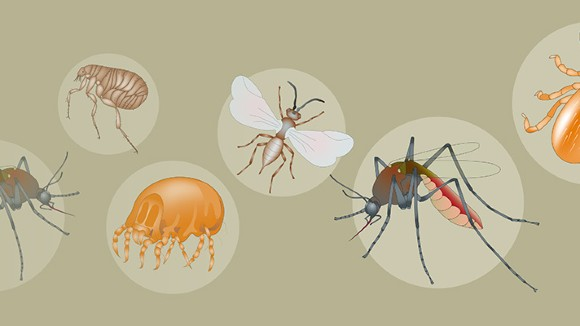

### parasitoidism

- Insects that kill their hosts (so more like predation)
- Larvae live as parasites within infected host

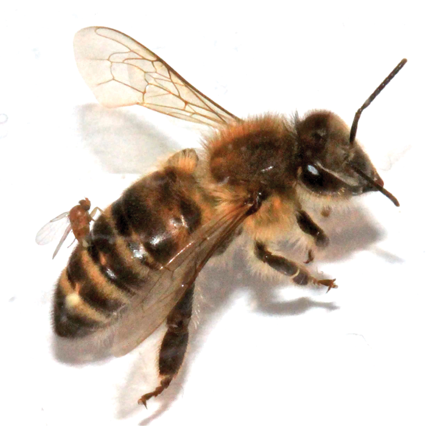

### micropredation

- attacks more than one host (reducing each host individual fitness by small amount)
- e.g., leeches, mosquitos, fleas, ticks, lice

### Diversity in tissue infected

- **Tissue tropism**: range of host tissue types which the pathogen can infect
- e.g., viruses tht must bind to specific cell surface receptors to enter a cell

### More on tissue tropism

### Diversity in impacts

- Some parasites have little impact (e.g., some parasitic worms), some have pronounced impact (e.g., anthrax)
- Impacts quantified as
  - morbidity/mortality
  - energetic cost to host
  - fitness cost
  - etc.

### Diversity in host specificity

- **Host specificity**: range and diversity of types of hosts a parasite can infect
- Generalism versus specialism
- Hosts can specialize
  - in number of hosts
  - in diversity of hosts

> What’s the most generalist parasite you can think of?

## End of lecture 1

### Why specialize?

- High infectivity/transmission in preferred host

### Why generalize?

- Need a host to reproduce
- Potential for invasion of new habitats
- Co-extinction is bad

### How do we quantify parasite specialism?

- number of host species infected (host range)
- relative utilization of different host species
- [maybe weighted by phylogenetic distance between hosts](https://pubmed.ncbi.nlm.nih.gov/12793652/)

### Specialism-generalism tradeoffs

- Jack of all trades, master of none?
  - Proposes a relationship between ability to infect and host specificity (e.g., low host specificity results in low average infection prevalence)

> But do we see evidence for this relationship?

### Host-parasite coevolution

- Infection is costly to hosts in terms of fitness, leading to evolution of host defenses
- Parasites *want* to infect, leading to evolution of novel infection strategies

> We will discuss this later in much more detail

### What is the “goal” of the parasite?

- To reproduce. So it doesn’t really *want* to kill the host, right?
- But it also has to reproduce and consume some aspect of the host, which comes at a fitness consequence for the host.
- There’s a conflicting balance between
  - trying to reproduce (which causes harm to host)
  - flying under the rader (transmission to the next host)

> We will go into more detail on this later as well

### optimal virulence

- **Virulence**: pathogen-induced mortality of infected host
- Dead hosts don’t transmit

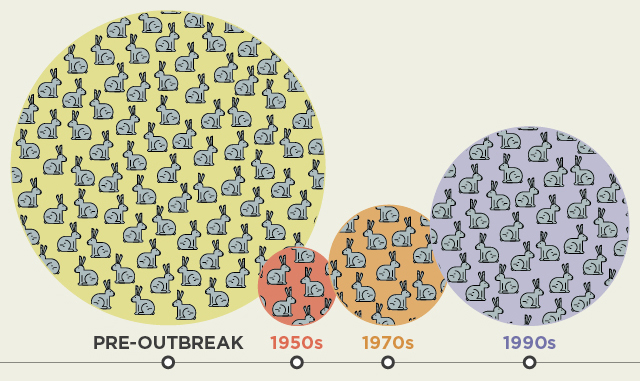

### What parasites would not follow this general pattern?

- Fungal pathogens, generally
- Pathogens with a long-lived environmental stage (e.g., anthrax)